# hw7

**Q1**

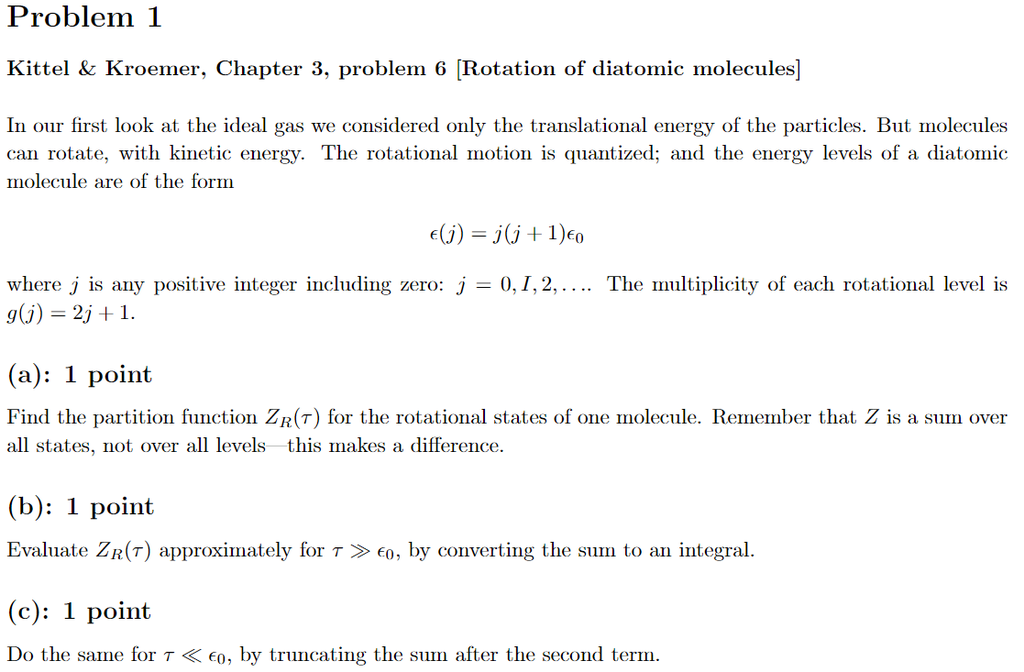

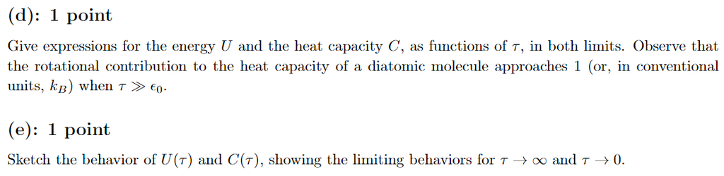

I believe we're starting with just rotation states, but translation for an ideal gas is

$$ Z_N = \frac{(\frac{n_Q}{n})^N}{N!} $$

(a) Partition function of one particle $Z_R(\tau)$

$$ Z = \sum_s e^{-\epsilon_s / \tau} \\ Z_R(\tau) = \sum_j g(j) e^{-\epsilon(j)/\tau} = \sum_j (2j+1) e^{-j(j+1)\epsilon_0/\tau} $$

(b) Converting to integral

Can we just replace the sum with an integral? I guess so. Looks doable.

$$ Z_R(\tau) =\int_0^\infty (2j+1)e^{-j(j+1)\epsilon_0/\tau} dj \\ x = (j^2+j)\epsilon_0/\tau \\ dx = (2j+1)dj \epsilon_0/\tau \\ Z_R(\tau) = \frac{\tau}{\epsilon_0} \int_0^\infty e^{-x} dx \\ = \frac{\tau}{\epsilon_0} $$

This result holds for $\tau \gg \epsilon_0$

(c) No integral required! Since the exponential gets small really quickly, we don't need to worry about $j=2$ or larger

$$ Z_R(\tau \ll \epsilon_0) = \sum_{j=0}^1 (2j+1) e^{-j(j+1)\epsilon_0/\tau} \\ = e^{-\epsilon_0/\tau} + 3e^{-2\epsilon_0/\tau} + \dots $$

(d)

$$ U = -\frac{\partial \ln Z}{\partial \beta} \\ C = \frac{dU}{d\tau} $$

I believe that we can separate out translational and rotational energy? Lets do it for $\tau \gg \epsilon_0$ and $\tau \ll \epsilon_0$ separately

Large $\tau:$ $$ U = -\frac{\partial }{\partial \beta} \ln \left(\frac{1}{\epsilon_0 \beta}\right) = \tau \\ C = 1 $$ Note that these are per-molecule values

Small $\tau:$ $$ U = -\frac{\partial }{\partial \beta} \ln \left(e^{-\epsilon_0 \beta}+3e^{-2\epsilon_0 \beta} \right) \\ = \frac{\epsilon_{0} e^{- \beta \epsilon_{0}} + 6 \epsilon_{0} e^{- 2 \beta \epsilon_{0}}}{e^{- \beta \epsilon_{0}} + 3 e^{- 2 \beta \epsilon_{0}}} = \frac{ \epsilon_0 + 6\epsilon_0 e^{-\epsilon_0/\tau}}{1+3e^{-\epsilon_{0}/\tau}} \\ C = \frac{dU}{d\tau} = \frac{6 \epsilon_{0}^{2} e^{- \frac{\epsilon_{0}}{\tau}}}{\tau^{2} \left(1 + 3 e^{- \frac{\epsilon_{0}}{\tau}}\right)} - \frac{18 \epsilon_{0}^{2} e^{- \frac{2 \epsilon_{0}}{\tau}}}{\tau^{2} \left(1 + 3 e^{- \frac{\epsilon_{0}}{\tau}}\right)^{2}} $$

I'll let my computer do the plotting

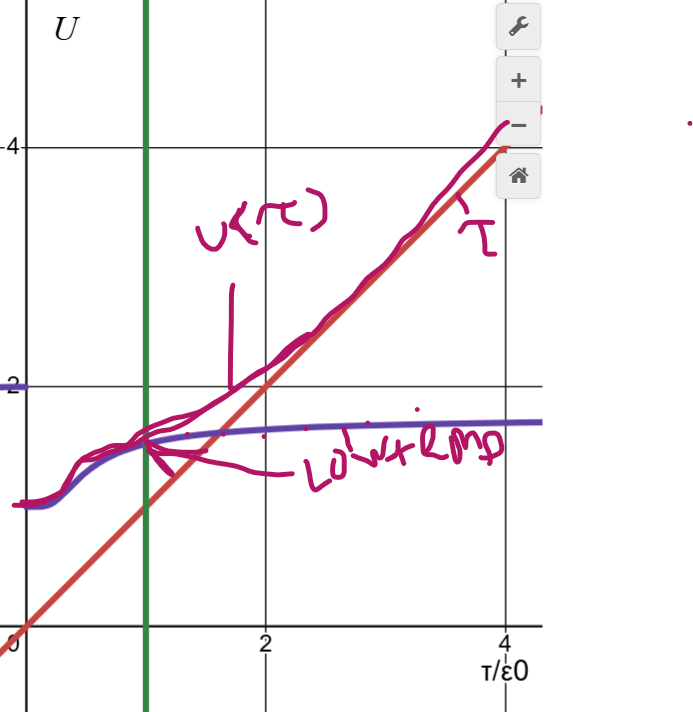

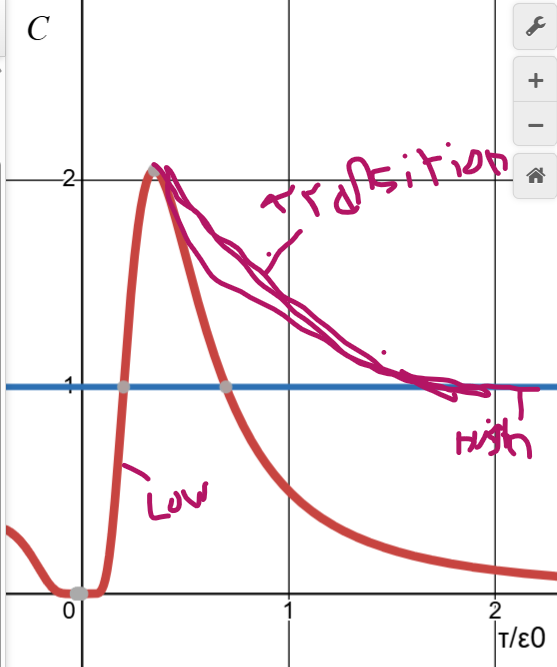

```python
import sympy as sp

e0, beta, tau = sp.symbols('epsilon_0 beta tau')
display(-sp.diff(sp.ln(1/(e0*beta)), beta))

display(-sp.diff(sp.ln(sp.exp(-e0*beta)+3*sp.exp(-2*e0*beta)), beta))

sp.diff(6*e0*sp.exp(-e0/tau)/(1+3*sp.exp(-e0/tau)), tau)
```

$\displaystyle \frac{1}{\beta}$

$\displaystyle - \frac{- \epsilon_{0} e^{- \beta \epsilon_{0}} - 6 \epsilon_{0} e^{- 2 \beta \epsilon_{0}}}{e^{- \beta \epsilon_{0}} + 3 e^{- 2 \beta \epsilon_{0}}}$

$\displaystyle \frac{6 \epsilon_{0}^{2} e^{- \frac{\epsilon_{0}}{\tau}}}{\tau^{2} \left(1 + 3 e^{- \frac{\epsilon_{0}}{\tau}}\right)} - \frac{18 \epsilon_{0}^{2} e^{- \frac{2 \epsilon_{0}}{\tau}}}{\tau^{2} \left(1 + 3 e^{- \frac{\epsilon_{0}}{\tau}}\right)^{2}}$

**Q2**

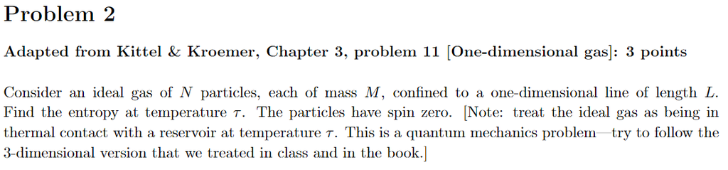

out of time sorry!

**Q3**

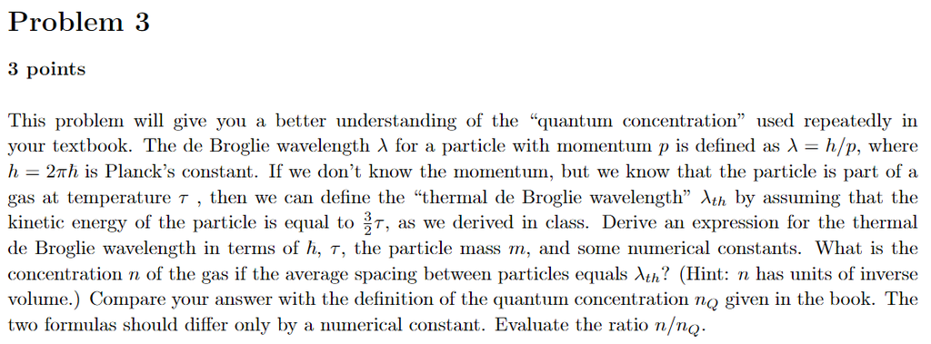

Easy enough!

$$ \frac{1}{2} mv^2 = \frac{3}{2} \tau \\ v = \sqrt{\frac{3\tau}{m}} \rightarrow mv = \sqrt{3\tau m} \\ \lambda_{th} = \frac{h}{p_{th}} = \frac{h}{mv} = \frac{2\pi \hbar}{\sqrt{3\tau m}} $$

$\lambda$ has units of length, so $\lambda^3$ is volume. If there is one particle per $\lambda^3$, we have

$$ n = \frac{1}{\lambda_{th}^3} = \left(\frac{\sqrt{3\tau m}}{2\pi \hbar} \right)^3 $$ Which essentially represents a cubic lattice of particles with lattice constant $\lambda_{th}$

In the book we have $n_Q \equiv \left(\frac{M\tau}{2 \pi \hbar^2}\right)^{3/2}$

$$ n = \left(\frac{3\tau m}{4\pi^2 \hbar^2} \right)^{3/2} \\ n_Q = \left(\frac{\tau m}{2 \pi \hbar^2}\right)^{3/2} \\ \frac{n}{n_Q} = \frac{3}{2\pi} $$

This implies that our cubic lattice spacing is a bit larger than the actual quantum concentration value, which I interpret as indicating particles can be squeezed in more accurately using a different lattice than cubic, among other ideas

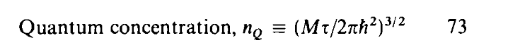

**Q4**

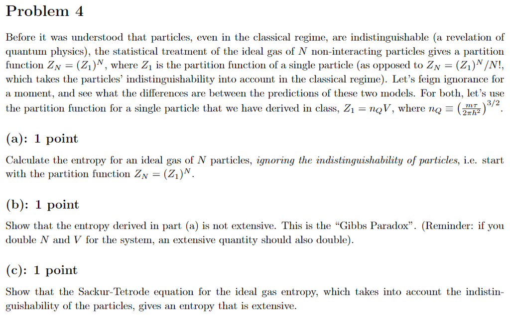

(a) Let's apply $\sigma = \frac{\partial }{\partial \tau} (\tau \ln Z)$

Classical: $Z_N = (Z_1)^N = (n_Q V)^N$ Note that $n_Q$ depends on $\tau$. Let's use $n_Q'$ independent of $\tau$

$$ n_Q = \tau^{3/2} n_Q' \\ n_Q' = \left( \frac{m}{2\pi \hbar^2}\right)^{3/2} \\ Z_N = \left(\tau^{3/2} n_Q' V\right)^N = \tau^{3N/2}\left( n_Q' V\right)^N \\ \ln(Z_n) = \frac{3N}{2} \ln (\tau) + N \ln(n_Q' V) $$ Now for $\sigma$

$$ \sigma = \frac{\partial}{\partial \tau} \left[\frac{3N\tau}{2} \ln (\tau) + N\tau \ln(n_Q' V) \right] \\ = N\ln\left(n_Q V \right) + \frac{3N}{2} $$

```python
import sympy as sp

N, tau, nQp, V = sp.symbols('N tau n\'_Q V')

differentiand = tau*sp.ln((tau**(3/2)*nQp*V)**N)
display(sp.diff(differentiand, tau))

differentiand = 3*N*tau/2 * sp.ln(tau) + N*tau*sp.ln(nQp*V)
display(sp.diff(differentiand, tau)) #yep, same result
```

$\displaystyle 1.5 N + \log{\left(\left(V n'_{Q} \tau^{1.5}\right)^{N} \right)}$

$\displaystyle \frac{3 N \log{\left(\tau \right)}}{2} + N \log{\left(V n'_{Q} \right)} + \frac{3 N}{2}$

[figure not shown]

(b) Not extensive: let's see what happens when $N$ and $V$ are doubled. I actually skipped forward and did (c) first, and it's clear our issues will come from $V$ not being divided by $N$ in the logarithm

$$ \sigma = N\ln(n_QV) + \frac{3N}{2} \\ \sigma' = 2N \ln(n_Q (2V)) + \frac{3(2N)}{2} \\ = 2\left(N\ln(2n_QV) + \frac{3N}{2}\right) = 2\sigma + 2N \ln 2 $$ In fact, doubling the number of particles will double entropy, while increasing $V$ does the weird algorithm thing.

(c) The Sackur-Tetrode equation for entropy is

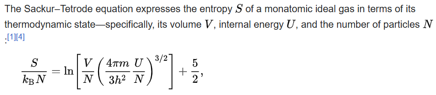

$\sigma = \frac{S}{k_B}$. Does internal energy depend on $N$ and $V$? Let's use the other equation

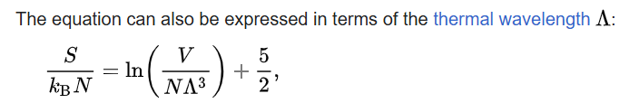

$$ \sigma = N \ln\left( \frac{V}{N\Lambda^3}\right) + N\frac{5}{2} \\ \sigma' = 2N \ln\left( \frac{2V}{2N\Lambda^3}\right) + 2N\frac{5}{2} = 2\left(N \ln\left( \frac{V}{N\Lambda^3}\right) + N\frac{5}{2}\right) = 2\sigma $$

Doubling $N$ and $V$ gave us $2\sigma$, so it all works out!